# Overview

```r
library(fastpng)
```

`{fastpng}` reads and writes PNG images.

`{fastpng}` exposes configuration options so that the user can make a trade-off between speed of writing and PNG size. These options include:

- Compression level
- Filter use
- Image transposition

For example, writing uncompressed PNG images can be 100x faster than writing with regular compression settings.

`fastpng` uses libspng - current v0.7.4

## Features

### Supported image data in R

Supported images each have examples in the `test_image` as part of this package.

- **Native rasters**
- **Rasters**
  - With hex colour formats: #RGB, #RGBA, #RRGGBB, #RRGGBBAA
  - Standard R colour names also supported e.g. ‘red’, ‘white’
- **Numeric arrays**
  - Values in range [0,1]
  - 1-, 2-, 3- and 4-plane numeric arrays (interpreted as gray, gray+alpha, RGB and RGBA images)
- **Integer arrays**
  - Values in range [0,255] treated as 8-bit values
  - Values in range [0,65535] treated as 16-bit for PNG writing
- **Integer matrix + an indexed palette of colours**
- **Raw vectors** with a specification for data layout

### Supported PNG image types

- 8-bit and 16-bit PNGs
- RGBA, RGB, Gray + Alpha, Gray PNGs
- Indexed colour PNGs
- RGB PNGs with a specified transparency colour (using [tRNS chunk](https://www.w3.org/TR/PNG-Chunks))

### Comparison to standard `{png}` library

|  | `{fastpng}` | `{png}` |
| --- | --- | --- |
| Numeric arrays | Yes | Yes |
| Native rasters | Yes | Yes |
| Rasters | Yes |  |
| Integer Arrays | Yes |  |
| Indexed PNGs | Yes |  |
| `tRNS` transparency | Yes |  |
| Configurable compression | Yes |  |
| Configurable filtering | Yes |  |
| Configurable transposition | Yes |  |

## Compression Settings: Speed / size tradeoff

The following graph shows the speed of writing and the compression ratio for various settings in `fastpng`. A data point for the `png` package is also shown.

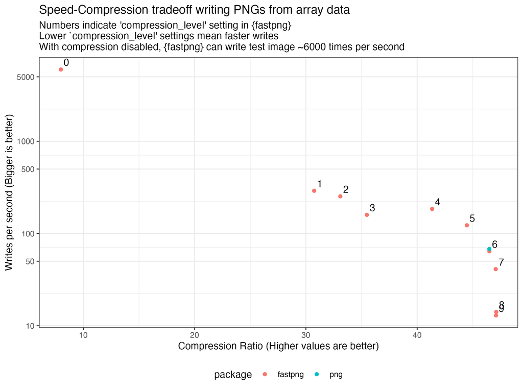

## Example: Read a PNG into R

```r
library(fastpng)
png_file <- system.file("img", "Rlogo.png", package="png")
fastpng::get_png_info(png_file)
```

```
#> $width
#> [1] 100
#>
#> $height
#> [1] 76
#>
#> $bit_depth
#> [1] 8
#>
#> $color_type
#> [1] 6
#>
#> $compression_method
#> [1] 0
#>
#> $filter_method
#> [1] 0
#>
#> $interlace_method
#> [1] 0
#>
#> $color_desc
#> [1] "SPNG_COLOR_TYPE_TRUECOLOR_ALPHA"
#>
#> $filter_desc
#> [1] "SPNG_FILTER_NONE"
#>
#> $interlate_desc
#> [1] "SPNG_INTERLACE_NONE"
```

[figure not shown]

```r
ras <- fastpng::read_png(png_file, type = 'raster')
grid::grid.raster(ras, interpolate = FALSE)
```

#### Read as a raster (of hex colours)

```r
ras <- fastpng::read_png(png_file, type = "raster")
ras[7:11, 79:83]
```

```
#>      [,1]        [,2]        [,3]        [,4]        [,5]
#> [1,] "#686D6597" "#7579711F" "#00000000" "#00000000" "#00000000"
#> [2,] "#5F645CFF" "#5D635AF9" "#63696098" "#7B80781C" "#00000000"
#> [3,] "#686D64FF" "#61665DFF" "#5B6158FF" "#5C6158F5" "#656A6280"
#> [4,] "#71766EFF" "#6B6F67FF" "#656A61FF" "#5E635BFF" "#595E55FF"
#> [5,] "#797D75FF" "#747971FF" "#6E736AFF" "#686D64FF" "#60655DFF"
```

#### Read as a numeric array

```r
ras <- fastpng::read_png(png_file, type = "array")
ras[7:11, 79:83, 1] # red channel
```

```
#>           [,1]      [,2]      [,3]      [,4]      [,5]
#> [1,] 0.4078431 0.4588235 0.0000000 0.0000000 0.0000000
#> [2,] 0.3725490 0.3647059 0.3882353 0.4823529 0.0000000
#> [3,] 0.4078431 0.3803922 0.3568627 0.3607843 0.3960784
#> [4,] 0.4431373 0.4196078 0.3960784 0.3686275 0.3490196
#> [5,] 0.4745098 0.4549020 0.4313725 0.4078431 0.3764706
```

#### Read as an integer array

```r
ras <- fastpng::read_png(png_file, type = "array", array_type = 'integer')
ras[7:11, 79:83, 1] # red channel
```

```
#>      [,1] [,2] [,3] [,4] [,5]
#> [1,]  104  117    0    0    0
#> [2,]   95   93   99  123    0
#> [3,]  104   97   91   92  101
#> [4,]  113  107  101   94   89
#> [5,]  121  116  110  104   96
```

#### Read as a native raster

```r
im <- fastpng::read_png(png_file, type = "nativeraster")
im[7:11, 79:83]
```

```
#>          [,1] [,2] [,3]     [,4]      [,5]
#> [1,] -7235693    0    0 -7301485  -7767184
#> [2,] -7367279    0    0 -7367022  -5864589
#> [3,] -7498608    0    0 -7301485  -4219764
#> [4,] -7432815    0    0 -7235692   -995135
#> [5,] -6648959    0    0 -7501694 -10268343
```

## Write an image to PNG with/without compression

```r
png_file <- tempfile()
fastpng::write_png(im, png_file)  # standard compression
file.size(png_file)
```

```
#> [1] 11938
```

```r
fastpng::write_png(im, png_file, compression_level = 0) # no compression, but fast!
file.size(png_file)
```

```
#> [1] 30580
```

## Write integer matrix as indexed PNG

```r
indices <- test_image$indexed$integer_index
palette <- test_image$indexed$palette

dim(indices)
```

```
#> [1] 200 300
```

```r
indices[1:10, 1:10]
```

```
#>       [,1] [,2] [,3] [,4] [,5] [,6] [,7] [,8] [,9] [,10]
#>  [1,]    0    0    0    0    0    0    0    0    0     0
#>  [2,]    0    0    0    0    0    0    0    0    0     0
#>  [3,]    0    0    0    0    0    0    0    0    0     1
#>  [4,]    0    0    0    0    0    0    0    1    1     1
#>  [5,]    0    0    0    0    0    1    1    1    1     1
#>  [6,]    0    0    0    0    1    1    1    1    1     1
#>  [7,]    0    0    0    0    1    1    1    1    1     1
#>  [8,]    0    0    0    1    1    1    1    1    1     1
#>  [9,]    0    0    0    1    1    1    1    1    1     2
#> [10,]    0    0    1    1    1    1    1    1    2     2
```

```r
palette[1:10]
```

```
#>  [1] "#440154FF" "#440256FF" "#450457FF" "#450559FF" "#46075AFF" "#46085CFF"
#>  [7] "#460A5DFF" "#460B5EFF" "#470D60FF" "#470E61FF"
```

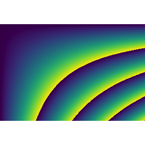

```r
tmp <- tempfile()
fastpng::write_png(image = indices, palette = palette, file = tmp)
```